# Assignment 1.2

Marcos Cunchillos Just

2026-10-08

## Exercise 1

The R **datasets** package provides a series of datasets to work with, such as `iris`, `cars` or `Titanic`. You should:

- Find a statistical summary of the variables of the **iris** and **Orange** datasets.

```r
# Summarize iris
data(iris)
head(iris)
```

|  | Sepal.Length | Sepal.Width | Petal.Length | Petal.Width | Species |
| --- | --- | --- | --- | --- | --- |
| 1 | 5.1 | 3.5 | 1.4 | 0.2 | setosa |
| 2 | 4.9 | 3.0 | 1.4 | 0.2 | setosa |
| 3 | 4.7 | 3.2 | 1.3 | 0.2 | setosa |
| 4 | 4.6 | 3.1 | 1.5 | 0.2 | setosa |
| 5 | 5.0 | 3.6 | 1.4 | 0.2 | setosa |
| 6 | 5.4 | 3.9 | 1.7 | 0.4 | setosa |

```r
summary(iris)
```

```
##   Sepal.Length    Sepal.Width     Petal.Length    Petal.Width
##  Min.   :4.300   Min.   :2.000   Min.   :1.000   Min.   :0.100
##  1st Qu.:5.100   1st Qu.:2.800   1st Qu.:1.600   1st Qu.:0.300
##  Median :5.800   Median :3.000   Median :4.350   Median :1.300
##  Mean   :5.843   Mean   :3.057   Mean   :3.758   Mean   :1.199
##  3rd Qu.:6.400   3rd Qu.:3.300   3rd Qu.:5.100   3rd Qu.:1.800
##  Max.   :7.900   Max.   :4.400   Max.   :6.900   Max.   :2.500
##        Species
##  setosa    :50
##  versicolor:50
##  virginica :50
##
##
##
```

```r
# Summarize Orange
data(Orange)
head(Orange)
```

|  | Tree | age | circumference |
| --- | --- | --- | --- |
| 1 | 1 | 118 | 30 |
| 2 | 1 | 484 | 58 |
| 3 | 1 | 664 | 87 |
| 4 | 1 | 1004 | 115 |
| 5 | 1 | 1231 | 120 |
| 6 | 1 | 1372 | 142 |

```r
summary(Orange)
```

```
##  Tree       age         circumference
##  3:7   Min.   : 118.0   Min.   : 30.0
##  1:7   1st Qu.: 484.0   1st Qu.: 65.5
##  5:7   Median :1004.0   Median :115.0
##  2:7   Mean   : 922.1   Mean   :115.9
##  4:7   3rd Qu.:1372.0   3rd Qu.:161.5
##        Max.   :1582.0   Max.   :214.0
```

- Generate a table of absolute and relative frequencies. Do all the generated tables make sense to you?

```r
# Absolute frequencies of the iris variables
kable(table(iris$Sepal.Length))
```

| Var1 | Freq |
| --- | --- |
| 4.3 | 1 |
| 4.4 | 3 |
| 4.5 | 1 |
| 4.6 | 4 |
| 4.7 | 2 |
| 4.8 | 5 |
| 4.9 | 6 |
| 5 | 10 |
| 5.1 | 9 |
| 5.2 | 4 |
| 5.3 | 1 |
| 5.4 | 6 |
| 5.5 | 7 |
| 5.6 | 6 |
| 5.7 | 8 |
| 5.8 | 7 |
| 5.9 | 3 |
| 6 | 6 |
| 6.1 | 6 |
| 6.2 | 4 |
| 6.3 | 9 |
| 6.4 | 7 |
| 6.5 | 5 |
| 6.6 | 2 |
| 6.7 | 8 |
| 6.8 | 3 |
| 6.9 | 4 |
| 7 | 1 |
| 7.1 | 1 |
| 7.2 | 3 |
| 7.3 | 1 |
| 7.4 | 1 |
| 7.6 | 1 |
| 7.7 | 4 |
| 7.9 | 1 |

```r
kable(table(iris$Sepal.Width))
```

| Var1 | Freq |
| --- | --- |
| 2 | 1 |
| 2.2 | 3 |
| 2.3 | 4 |
| 2.4 | 3 |
| 2.5 | 8 |
| 2.6 | 5 |
| 2.7 | 9 |
| 2.8 | 14 |
| 2.9 | 10 |
| 3 | 26 |
| 3.1 | 11 |
| 3.2 | 13 |
| 3.3 | 6 |
| 3.4 | 12 |
| 3.5 | 6 |
| 3.6 | 4 |
| 3.7 | 3 |
| 3.8 | 6 |
| 3.9 | 2 |
| 4 | 1 |
| 4.1 | 1 |
| 4.2 | 1 |
| 4.4 | 1 |

```r
kable(table(iris$Petal.Width))
```

| Var1 | Freq |
| --- | --- |
| 0.1 | 5 |
| 0.2 | 29 |
| 0.3 | 7 |
| 0.4 | 7 |
| 0.5 | 1 |
| 0.6 | 1 |
| 1 | 7 |
| 1.1 | 3 |
| 1.2 | 5 |
| 1.3 | 13 |
| 1.4 | 8 |
| 1.5 | 12 |
| 1.6 | 4 |
| 1.7 | 2 |
| 1.8 | 12 |
| 1.9 | 5 |
| 2 | 6 |
| 2.1 | 6 |
| 2.2 | 3 |
| 2.3 | 8 |
| 2.4 | 3 |
| 2.5 | 3 |

```r
kable(table(iris$Petal.Length))
```

| Var1 | Freq |
| --- | --- |
| 1 | 1 |
| 1.1 | 1 |
| 1.2 | 2 |
| 1.3 | 7 |
| 1.4 | 13 |
| 1.5 | 13 |
| 1.6 | 7 |
| 1.7 | 4 |
| 1.9 | 2 |
| 3 | 1 |
| 3.3 | 2 |
| 3.5 | 2 |
| 3.6 | 1 |
| 3.7 | 1 |
| 3.8 | 1 |
| 3.9 | 3 |
| 4 | 5 |
| 4.1 | 3 |
| 4.2 | 4 |
| 4.3 | 2 |
| 4.4 | 4 |
| 4.5 | 8 |
| 4.6 | 3 |
| 4.7 | 5 |
| 4.8 | 4 |
| 4.9 | 5 |
| 5 | 4 |
| 5.1 | 8 |
| 5.2 | 2 |
| 5.3 | 2 |
| 5.4 | 2 |
| 5.5 | 3 |
| 5.6 | 6 |
| 5.7 | 3 |
| 5.8 | 3 |
| 5.9 | 2 |
| 6 | 2 |
| 6.1 | 3 |
| 6.3 | 1 |
| 6.4 | 1 |
| 6.6 | 1 |
| 6.7 | 2 |
| 6.9 | 1 |

```r
kable(table(iris$Species))
```

| Var1 | Freq |
| --- | --- |
| setosa | 50 |
| versicolor | 50 |
| virginica | 50 |

```r
# Relative frequencies of the iris variables
kable(prop.table(table(iris$Sepal.Length)))
```

| Var1 | Freq |
| --- | --- |
| 4.3 | 0.0066667 |
| 4.4 | 0.0200000 |
| 4.5 | 0.0066667 |
| 4.6 | 0.0266667 |
| 4.7 | 0.0133333 |
| 4.8 | 0.0333333 |
| 4.9 | 0.0400000 |
| 5 | 0.0666667 |
| 5.1 | 0.0600000 |
| 5.2 | 0.0266667 |
| 5.3 | 0.0066667 |
| 5.4 | 0.0400000 |
| 5.5 | 0.0466667 |
| 5.6 | 0.0400000 |
| 5.7 | 0.0533333 |
| 5.8 | 0.0466667 |
| 5.9 | 0.0200000 |
| 6 | 0.0400000 |
| 6.1 | 0.0400000 |
| 6.2 | 0.0266667 |
| 6.3 | 0.0600000 |
| 6.4 | 0.0466667 |
| 6.5 | 0.0333333 |
| 6.6 | 0.0133333 |
| 6.7 | 0.0533333 |
| 6.8 | 0.0200000 |
| 6.9 | 0.0266667 |
| 7 | 0.0066667 |
| 7.1 | 0.0066667 |
| 7.2 | 0.0200000 |
| 7.3 | 0.0066667 |
| 7.4 | 0.0066667 |
| 7.6 | 0.0066667 |
| 7.7 | 0.0266667 |
| 7.9 | 0.0066667 |

```r
kable(prop.table(table(iris$Sepal.Width)))
```

| Var1 | Freq |
| --- | --- |
| 2 | 0.0066667 |
| 2.2 | 0.0200000 |
| 2.3 | 0.0266667 |
| 2.4 | 0.0200000 |
| 2.5 | 0.0533333 |
| 2.6 | 0.0333333 |
| 2.7 | 0.0600000 |
| 2.8 | 0.0933333 |
| 2.9 | 0.0666667 |
| 3 | 0.1733333 |
| 3.1 | 0.0733333 |
| 3.2 | 0.0866667 |
| 3.3 | 0.0400000 |
| 3.4 | 0.0800000 |
| 3.5 | 0.0400000 |
| 3.6 | 0.0266667 |
| 3.7 | 0.0200000 |
| 3.8 | 0.0400000 |
| 3.9 | 0.0133333 |
| 4 | 0.0066667 |
| 4.1 | 0.0066667 |
| 4.2 | 0.0066667 |
| 4.4 | 0.0066667 |

```r
kable(prop.table(table(iris$Petal.Length)))
```

| Var1 | Freq |
| --- | --- |
| 1 | 0.0066667 |
| 1.1 | 0.0066667 |
| 1.2 | 0.0133333 |
| 1.3 | 0.0466667 |
| 1.4 | 0.0866667 |
| 1.5 | 0.0866667 |
| 1.6 | 0.0466667 |
| 1.7 | 0.0266667 |
| 1.9 | 0.0133333 |
| 3 | 0.0066667 |
| 3.3 | 0.0133333 |
| 3.5 | 0.0133333 |
| 3.6 | 0.0066667 |
| 3.7 | 0.0066667 |
| 3.8 | 0.0066667 |
| 3.9 | 0.0200000 |
| 4 | 0.0333333 |
| 4.1 | 0.0200000 |
| 4.2 | 0.0266667 |
| 4.3 | 0.0133333 |
| 4.4 | 0.0266667 |
| 4.5 | 0.0533333 |
| 4.6 | 0.0200000 |
| 4.7 | 0.0333333 |
| 4.8 | 0.0266667 |
| 4.9 | 0.0333333 |
| 5 | 0.0266667 |
| 5.1 | 0.0533333 |
| 5.2 | 0.0133333 |
| 5.3 | 0.0133333 |
| 5.4 | 0.0133333 |
| 5.5 | 0.0200000 |
| 5.6 | 0.0400000 |
| 5.7 | 0.0200000 |
| 5.8 | 0.0200000 |
| 5.9 | 0.0133333 |
| 6 | 0.0133333 |
| 6.1 | 0.0200000 |
| 6.3 | 0.0066667 |
| 6.4 | 0.0066667 |
| 6.6 | 0.0066667 |
| 6.7 | 0.0133333 |
| 6.9 | 0.0066667 |

```r
kable(prop.table(table(iris$Petal.Width)))
```

| Var1 | Freq |
| --- | --- |
| 0.1 | 0.0333333 |
| 0.2 | 0.1933333 |
| 0.3 | 0.0466667 |
| 0.4 | 0.0466667 |
| 0.5 | 0.0066667 |
| 0.6 | 0.0066667 |
| 1 | 0.0466667 |
| 1.1 | 0.0200000 |
| 1.2 | 0.0333333 |
| 1.3 | 0.0866667 |
| 1.4 | 0.0533333 |
| 1.5 | 0.0800000 |
| 1.6 | 0.0266667 |
| 1.7 | 0.0133333 |
| 1.8 | 0.0800000 |
| 1.9 | 0.0333333 |
| 2 | 0.0400000 |
| 2.1 | 0.0400000 |
| 2.2 | 0.0200000 |
| 2.3 | 0.0533333 |
| 2.4 | 0.0200000 |
| 2.5 | 0.0200000 |

```r
kable(prop.table(table(iris$Species)))
```

| Var1 | Freq |
| --- | --- |
| setosa | 0.3333333 |
| versicolor | 0.3333333 |
| virginica | 0.3333333 |

- Generate a table of absolute frequencies for each of the variables of the **Orange** dataset. Do all the generated tables make sense to you?

```r
# Absolute frequencies of the Orange variables
kable(table(Orange$Tree))
```

| Var1 | Freq |
| --- | --- |
| 3 | 7 |
| 1 | 7 |
| 5 | 7 |
| 2 | 7 |
| 4 | 7 |

```r
kable(table(Orange$age))
```

| Var1 | Freq |
| --- | --- |
| 118 | 5 |
| 484 | 5 |
| 664 | 5 |
| 1004 | 5 |
| 1231 | 5 |
| 1372 | 5 |
| 1582 | 5 |

```r
kable(table(Orange$circumference))
```

| Var1 | Freq |
| --- | --- |
| 30 | 3 |
| 32 | 1 |
| 33 | 1 |
| 49 | 1 |
| 51 | 1 |
| 58 | 1 |
| 62 | 1 |
| 69 | 1 |
| 75 | 1 |
| 81 | 1 |
| 87 | 1 |
| 108 | 1 |
| 111 | 1 |
| 112 | 1 |
| 115 | 2 |
| 120 | 1 |
| 125 | 1 |
| 139 | 1 |
| 140 | 1 |
| 142 | 2 |
| 145 | 1 |
| 156 | 1 |
| 167 | 1 |
| 172 | 1 |
| 174 | 1 |
| 177 | 1 |
| 179 | 1 |
| 203 | 2 |
| 209 | 1 |
| 214 | 1 |

Here it is a bit mixed. `Tree` (5 trees, 7 measurements each) and `age` (7 measurement days, 5 trees each) make sense because they are identifiers of the design, not real measurements. `circumference` is continuous, so its table is mostly counts of 1 and tells us nothing.

- Generate a two-way table between the variables `Tree` and `age` of **Orange**.

```r
table(Orange$Tree, Orange$age)
```

```
##
##     118 484 664 1004 1231 1372 1582
##   3   1   1   1    1    1    1    1
##   1   1   1   1    1    1    1    1
##   5   1   1   1    1    1    1    1
##   2   1   1   1    1    1    1    1
##   4   1   1   1    1    1    1    1
```

Every cell is 1: each tree was measured once on each of the 7 days, so the design is completely balanced and there are no missing measurements.

## Exercise 2

Copy and run the following code for the two vectors:

```r
vect1 <- c(1,2,1,2,1,2,1,2,1,2,1,1,1,1,2,2,1,1,2,1)
vect2 <- c(1,1,2,2,2,1,2,1,1,2,1,2,1,1,1,2,1,1,1,1)
```

**a)** Using `vect1`, create a new vector called `low_weight` that is a factor with two levels. The labels correspond to 1 = “Low weight” and 2 = “Normal weight”.

```r
low_weight <- factor(vect1, levels = c(1, 2), labels = c("Low weight", "Normal weight"))
```

**b)** Using `vect2`, create a new vector called `smoker` that is a factor with two levels. The labels correspond to 1 = “Smoker” and 2 = “Non-smoker”.

```r
smoker <- factor(vect2, levels = c(1, 2), labels = c("Smoker", "Non-smoker"))
```

**c)** Create a contingency table with the two previous variables, named `contingency_table`.

```r
contingency_table <- table(low_weight, smoker)
contingency_table
```

```
##                smoker
## low_weight      Smoker Non-smoker
##   Low weight         8          4
##   Normal weight      5          3
```

**d)** Examine the relationship between the two variables using the chi-squared test.

```r
# warning = TRUE on purpose: with so few observations R warns that the
# chi-squared approximation may be incorrect, which is why Fisher's test follows
chisq.test(contingency_table)
```

[output not shown]

```
##
##  Pearson's Chi-squared test with Yates' continuity correction
##
## data:  contingency_table
## X-squared = 0, df = 1, p-value = 1
```

**e)** Also check the result of Fisher’s exact test.

```r
fisher.test(contingency_table)
```

```
##
##  Fisher's Exact Test for Count Data
##
## data:  contingency_table
## p-value = 1
## alternative hypothesis: true odds ratio is not equal to 1
## 95 percent confidence interval:
##   0.1200513 10.9278345
## sample estimates:
## odds ratio
##   1.189031
```

## Exercise 3

**a)** Load the **airquality** dataset from the **datasets** package and generate the following plots:

- A scatter plot of the variable `Ozone` in blue, using hash symbols (#) instead of dots.

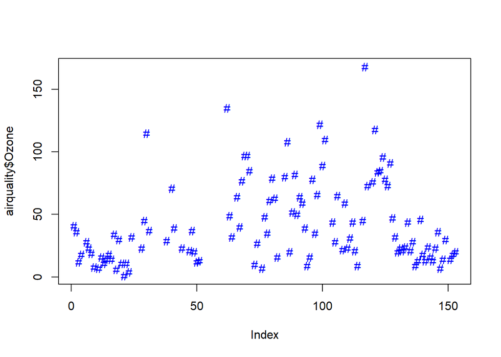

```r
data("airquality")
plot(airquality$Ozone, col = "blue", pch = "#")
```

- A red boxplot of the variable `Temp`, with the title “Temperature (in degrees Fahrenheit)”.

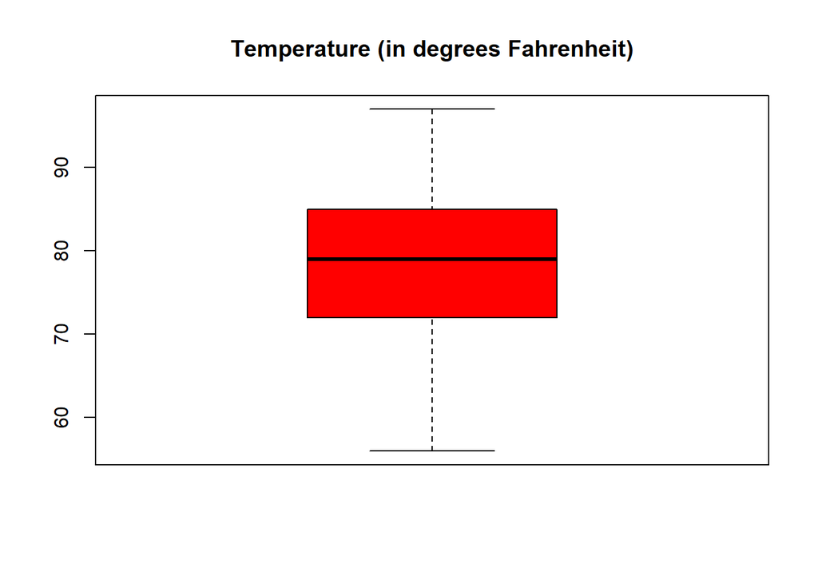

```r
boxplot(airquality$Temp, col = "red", main = "Temperature (in degrees Fahrenheit)")
```

**b)** Load the **airmiles** dataset from the **datasets** package and generate the following plots:

- A line plot of the `airmiles` series, titled “Commercial flight passenger data (in thousands)”, in blue (`cadetblue2`), with the x-axis label “Thousands of passengers”.

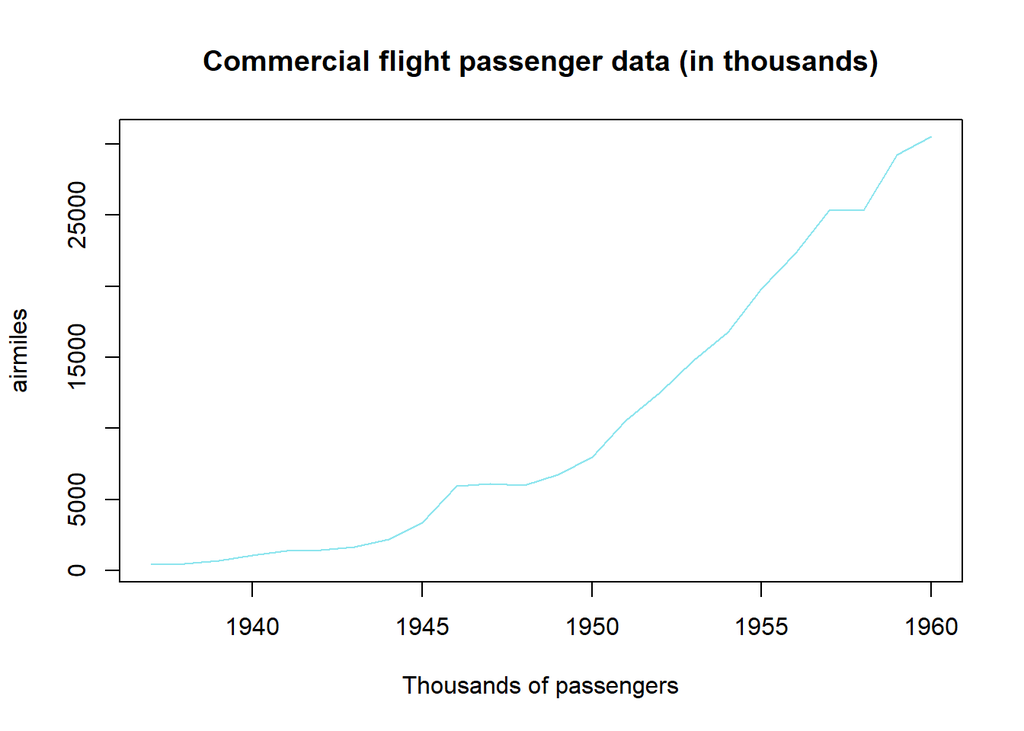

```r
data("airmiles")
plot(airmiles,
     main = "Commercial flight passenger data (in thousands)",
     xlab = "Thousands of passengers",
     col  = "cadetblue2")
```

- A histogram of the `airmiles` series in brown (`chocolate2`).

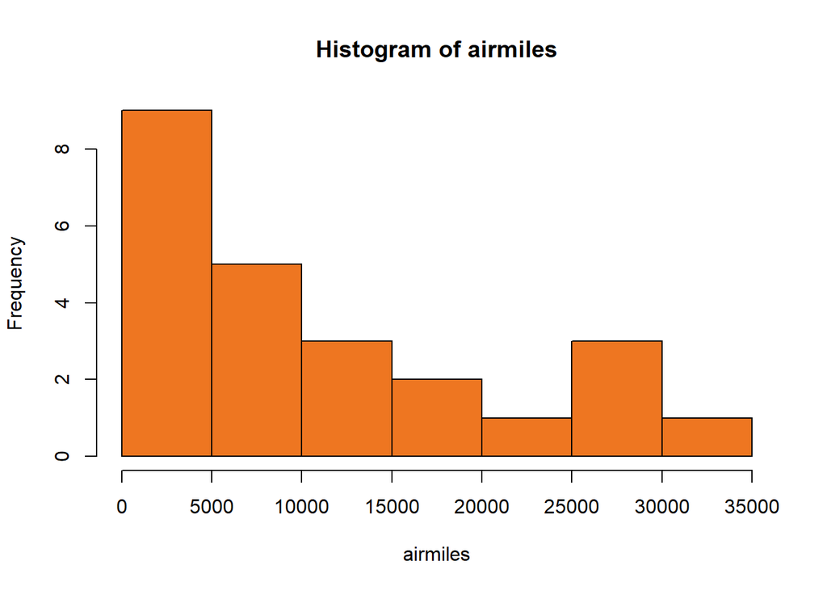

```r
hist(airmiles, col = "chocolate2")
```

**c)** Display the four plots together in a single image.

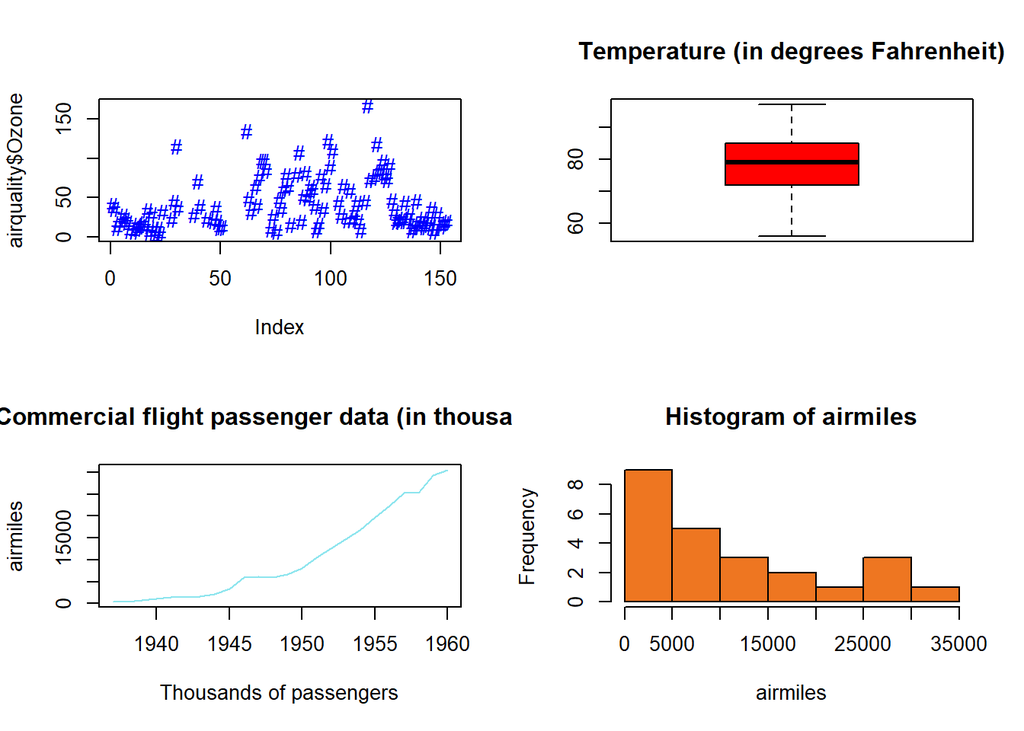

```r
par(mfrow = c(2, 2))

plot(airquality$Ozone, col = "blue", pch = "#")
boxplot(airquality$Temp, col = "red", main = "Temperature (in degrees Fahrenheit)")
plot(airmiles,
     main = "Commercial flight passenger data (in thousands)",
     xlab = "Thousands of passengers",
     col  = "cadetblue2")
hist(airmiles, col = "chocolate2")
```

```r
# Restore the default single-plot layout
par(mfrow = c(1, 1))
```

## Exercise 4

Try to reproduce example 7 of this lab with data simulated by you. They do not need to be similar, but you must be able to produce different statistical plots with the `plot()` command.

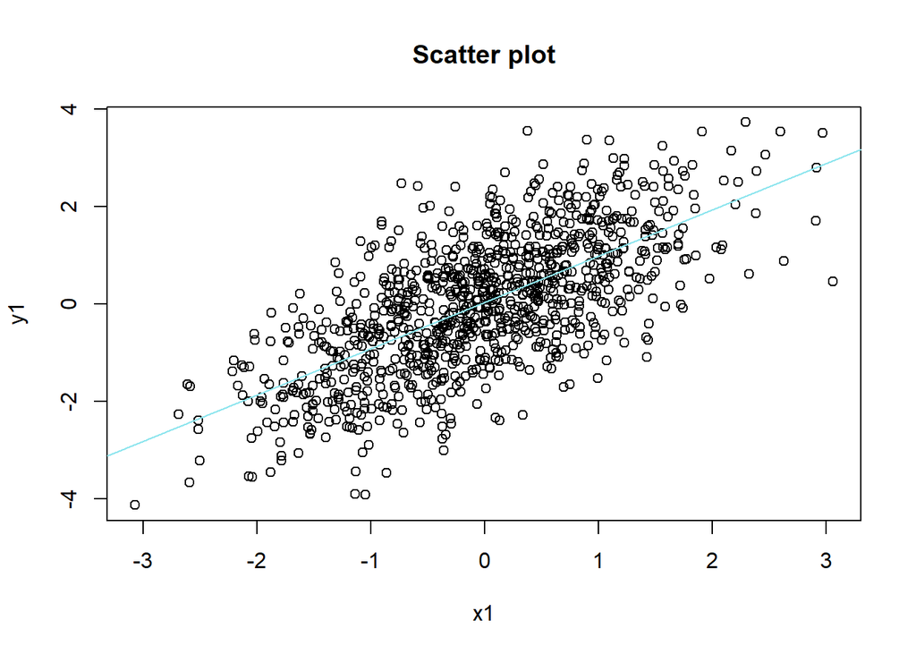

```r
set.seed(999)
x1 <- rnorm(1000)         # simulate a variable x1
y1 <- x1 + rnorm(1000)    # simulate y1 as x1 plus random noise

# Scatter plot with the least-squares line (y1 as a function of x1)
plot(x1, y1, main = "Scatter plot")
abline(lm(y1 ~ x1), col = "cadetblue2")
```

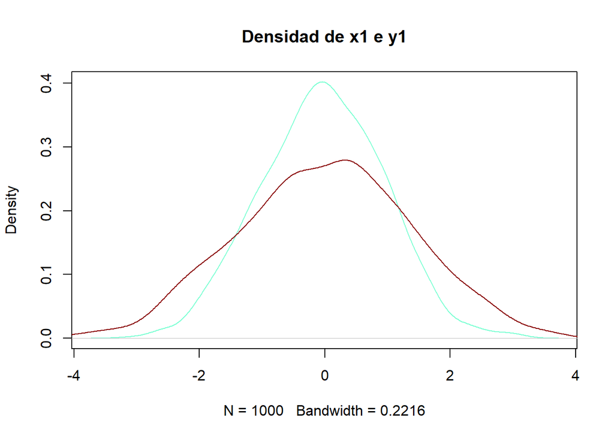

```r
# Density curves of both variables
plot(density(x1), main = "Densidad de x1 e y1", col = "aquamarine")
lines(density(y1), col = "darkred")
```

## Exercise 5

To practice creating plots with **ggplot2**, we will create six plots with different characteristics, using datasets from the packages used previously.

**a)** Using the **airquality** data from the **datasets** package, create a simple scatter plot with the fitted regression line in red (`darkred`).

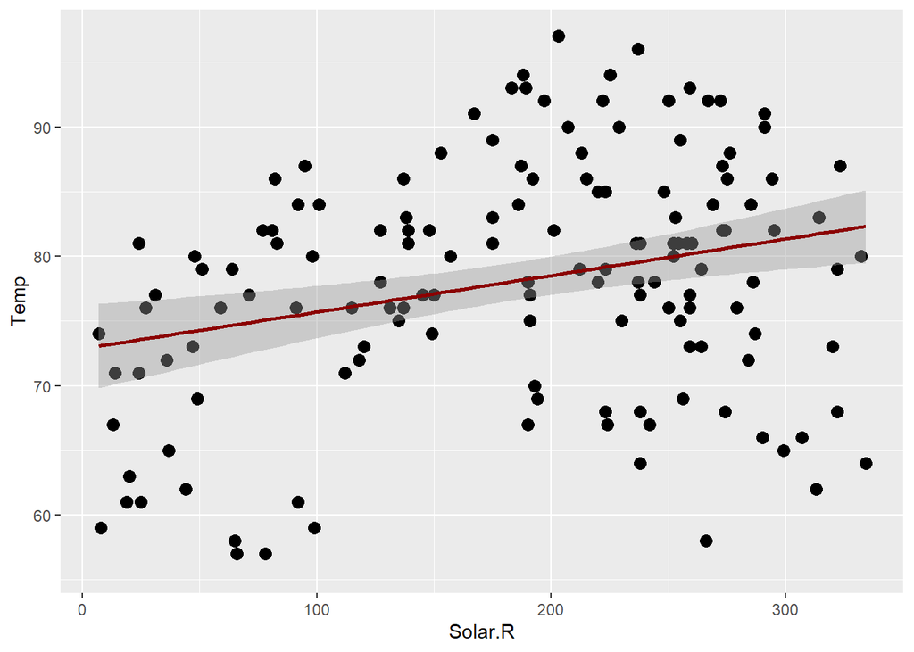

```r
ggplot(airquality, aes(Solar.R, Temp)) +
  geom_point(size = 3) +
  geom_smooth(method = "lm", colour = "darkred")
```

**b)** Using the **airquality** data from the **datasets** package, create a scatter plot of the variables `Solar.R` and `Temp` with their respective axis labels. The colours and the shape of the points must depend on the variable `Month` converted to a factor.

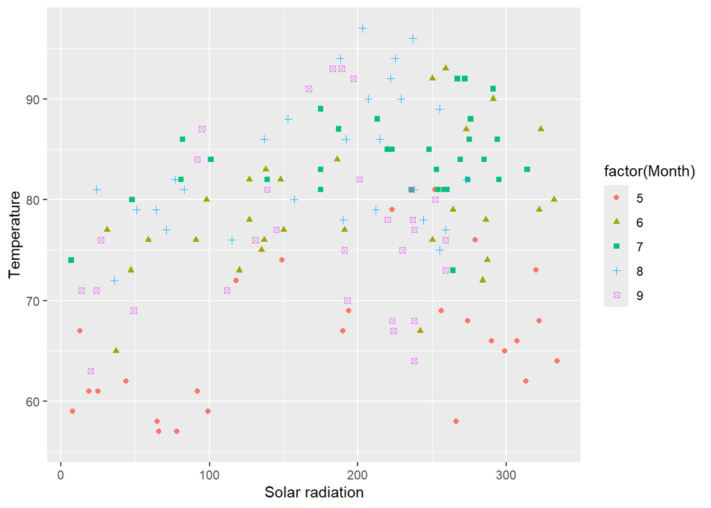

```r
ggplot(airquality, aes(Solar.R, Temp, colour = factor(Month), shape = factor(Month))) +
  geom_point() +
  labs(x = "Solar radiation", y = "Temperature")
```

**c)** Using the **birthwt** data from the **MASS** package, show the distribution of the variable `age` with a black border and a blue interior in the bars.

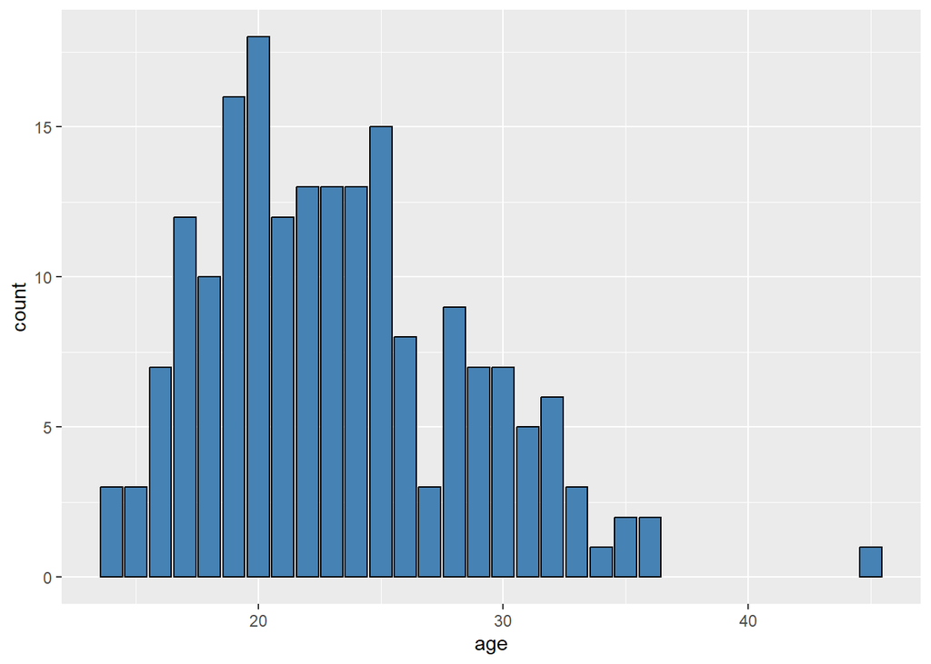

```r
ggplot(birthwt, aes(age)) +
  geom_bar(fill = "steelblue", colour = "black")
```

**d)** Using the **birthwt** data from the **MASS** package, show the distribution of the variable `age`, split into two plots (smoker / non-smoker) by the variable `smoke`.

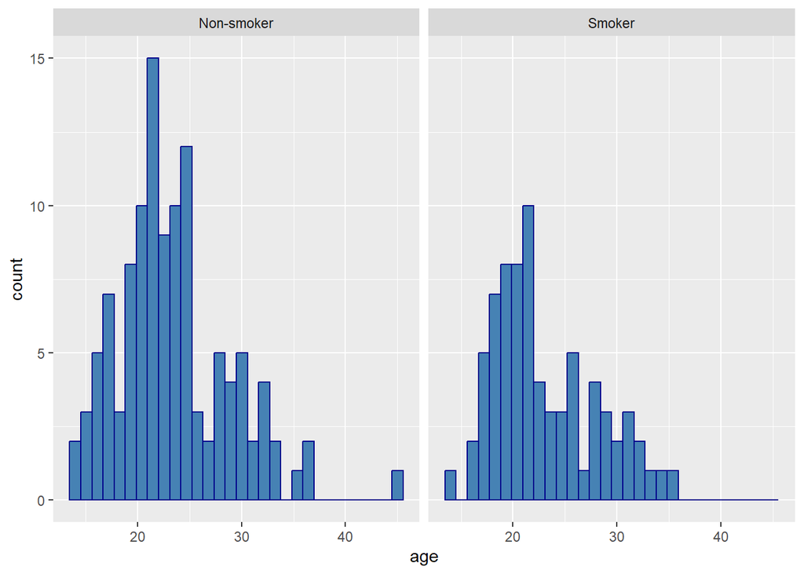

```r
birthwt$smoke_f <- factor(birthwt$smoke,
                          levels = c(0, 1),
                          labels = c("Non-smoker", "Smoker"))

ggplot(birthwt, aes(x = age)) +
  geom_histogram(fill = "steelblue", colour = "darkblue") +
  facet_wrap(~ smoke_f)
```

## Exercise 6

Create a plot with data taken from R’s **datasets** package and save it as an image (.jpg) named `migrafic1` and also as a PDF document named `migrafic2`.

```r
# Build the plot once and reuse it
p_age <- ggplot(birthwt, aes(age)) +
  geom_bar(fill = "steelblue", colour = "black")

# Export as JPG
jpeg("migrafic1.jpg")
print(p_age)    # ggplot objects must be printed explicitly inside a device
dev.off()       # dev.off() must be CALLED, with parentheses, to write the file
```

```r
# Export as PDF
pdf("migrafic2.pdf")
print(p_age)
dev.off()
```

## Exercise 7

- We want to know what circumference a tree will have six hundred days after planting. Create a linear model for this and practise linear regression step by step, following the steps seen in this lab.

### Step 1: access the data

```r
data("Orange")
head(Orange)
```

|  | Tree | age | circumference |
| --- | --- | --- | --- |
| 1 | 1 | 118 | 30 |
| 2 | 1 | 484 | 58 |
| 3 | 1 | 664 | 87 |
| 4 | 1 | 1004 | 115 |
| 5 | 1 | 1231 | 120 |
| 6 | 1 | 1372 | 142 |

### Step 2: summarise the variables to analyse

```r
str(Orange)
```

```
## Classes 'nfnGroupedData', 'nfGroupedData', 'groupedData' and 'data.frame':   35 obs. of  3 variables:
##  $ Tree         : Ord.factor w/ 5 levels "3"<"1"<"5"<"2"<..: 2 2 2 2 2 2 2 4 4 4 ...
##  $ age          : num  118 484 664 1004 1231 ...
##  $ circumference: num  30 58 87 115 120 142 145 33 69 111 ...
##  - attr(*, "formula")=Class 'formula'  language circumference ~ age | Tree
##   .. ..- attr(*, ".Environment")=<environment: R_EmptyEnv>
##  - attr(*, "labels")=List of 2
##   ..$ x: chr "Time since December 31, 1968"
##   ..$ y: chr "Trunk circumference"
##  - attr(*, "units")=List of 2
##   ..$ x: chr "(days)"
##   ..$ y: chr "(mm)"
```

```r
summary(Orange)
```

```
##  Tree       age         circumference
##  3:7   Min.   : 118.0   Min.   : 30.0
##  1:7   1st Qu.: 484.0   1st Qu.: 65.5
##  5:7   Median :1004.0   Median :115.0
##  2:7   Mean   : 922.1   Mean   :115.9
##  4:7   3rd Qu.:1372.0   3rd Qu.:161.5
##        Max.   :1582.0   Max.   :214.0
```

### Step 3: scatter plots of the variables, two at a time

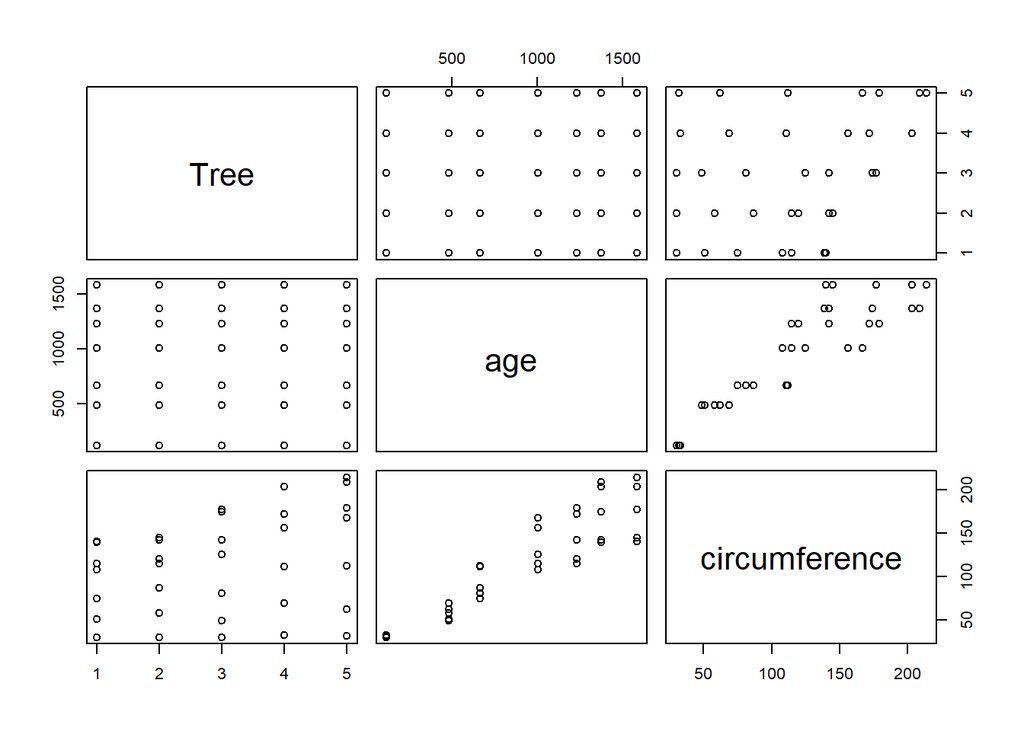

```r
pairs(Orange)
```

### Step 4: Pearson correlation coefficient

```r
cor(Orange$circumference, Orange$age)
```

```
## [1] 0.9135189
```

### Step 5: fit the regression model

If we find a relationship between the two variables, we fit the linear model.

```r
model <- lm(circumference ~ age, data = Orange)
summary(model)
```

```
##
## Call:
## lm(formula = circumference ~ age, data = Orange)
##
## Residuals:
##     Min      1Q  Median      3Q     Max
## -46.310 -14.946  -0.076  19.697  45.111
##
## Coefficients:
##              Estimate Std. Error t value Pr(>|t|)
## (Intercept) 17.399650   8.622660   2.018   0.0518 .
## age          0.106770   0.008277  12.900 1.93e-14 ***
## ---
## Signif. codes:  0 '***' 0.001 '**' 0.01 '*' 0.05 '.' 0.1 ' ' 1
##
## Residual standard error: 23.74 on 33 degrees of freedom
## Multiple R-squared:  0.8345, Adjusted R-squared:  0.8295
## F-statistic: 166.4 on 1 and 33 DF,  p-value: 1.931e-14
```

### Step 6: scatter plot and fitted least-squares line

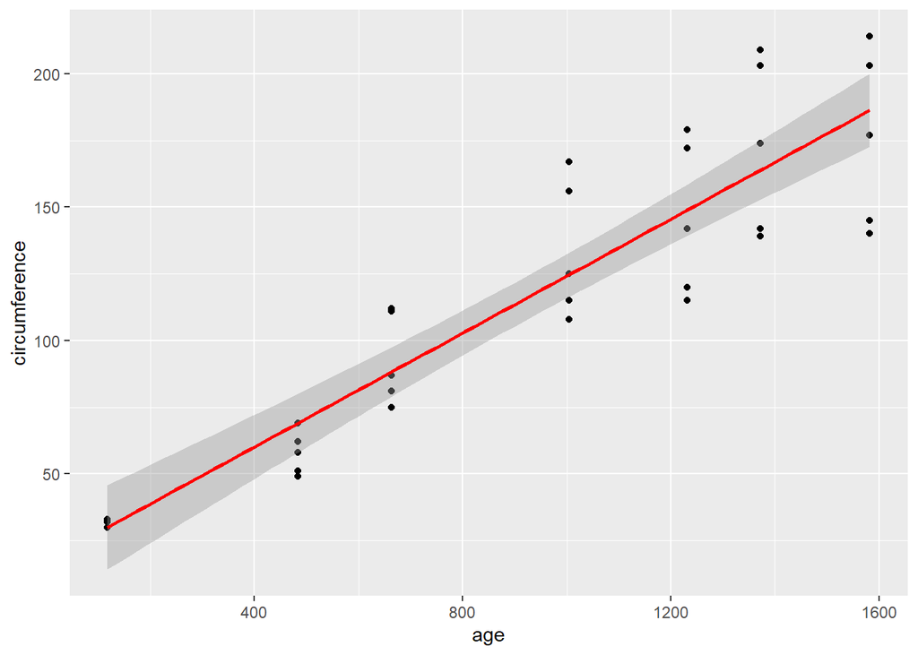

```r
ggplot(Orange, aes(x = age, y = circumference)) +
  geom_point() +
  geom_smooth(method = "lm", colour = "red")
```

### Step 7: check the results

We are interested in the estimated parameters of the model and in the goodness of fit of the line, given by the coefficient of determination (R-squared). We can also look at the p-value, which in inference gives the probability of obtaining a value equal to or more extreme than the observed one, assuming a null hypothesis is true. A result is statistically significant if its p-value is less than or equal to 0.05.

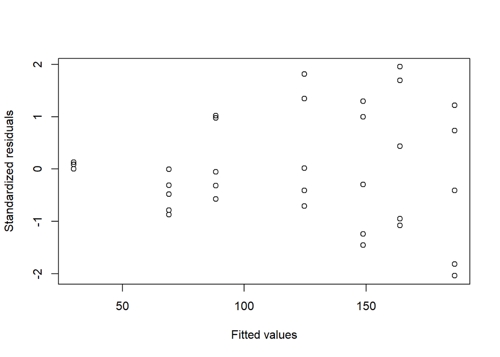

```r
res <- rstandard(model)
predicted_values <- fitted(model)

plot(predicted_values, res,
     xlab = "Fitted values", ylab = "Standardized residuals")
```

### Step 8: validate the model

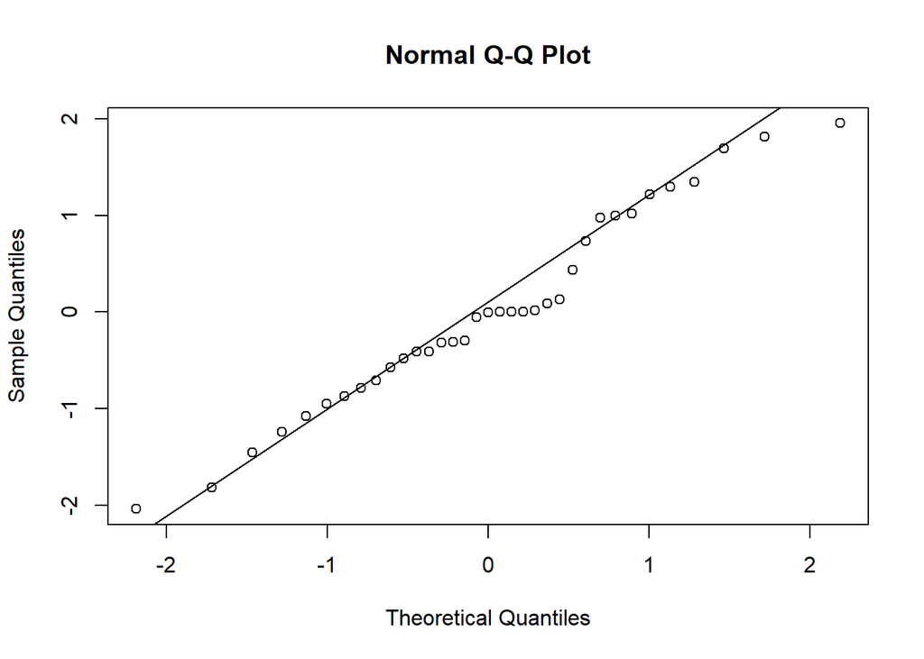

```r
qqnorm(res)
qqline(res)
```

### Step 9: point prediction

If required, we can obtain a point prediction from our model with `predict()` and the new data.

```r
pred_age <- data.frame(age = 600)
predict(model, pred_age)
```

```
##        1
## 81.46185
```

## Exercise 8

Load the **PlantGrowth** dataset from R’s **datasets** package. This file contains the results of an experiment to compare mean yields, measured as the dry weight of the plants (`weight`), obtained under a control and two different treatment conditions (`group` factor).

- Do you think there are differences between treatments?

### Step 1: load the data

```r
data("PlantGrowth")
head(PlantGrowth)
```

|  | weight | group |
| --- | --- | --- |
| 1 | 4.17 | ctrl |
| 2 | 5.58 | ctrl |
| 3 | 5.18 | ctrl |
| 4 | 6.11 | ctrl |
| 5 | 4.50 | ctrl |
| 6 | 4.61 | ctrl |

### Step 2: summarise the data

```r
summary(PlantGrowth)
```

```
##      weight       group
##  Min.   :3.590   ctrl:10
##  1st Qu.:4.550   trt1:10
##  Median :5.155   trt2:10
##  Mean   :5.073
##  3rd Qu.:5.530
##  Max.   :6.310
```

### Step 3: look for significant outliers

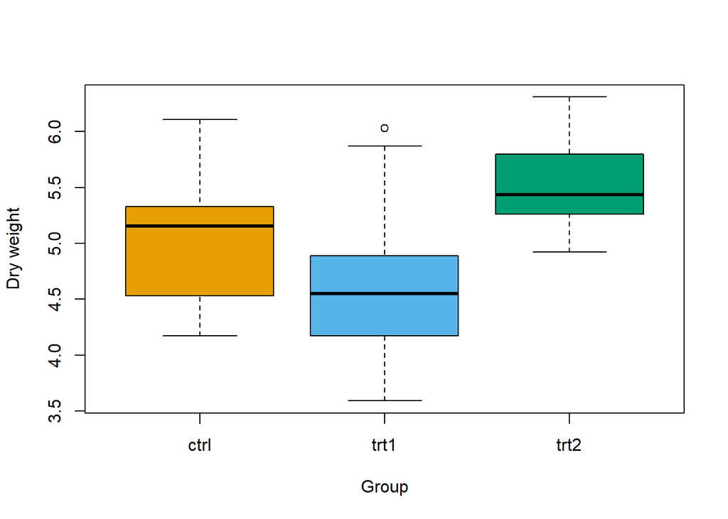

```r
# palette.colors() starts with black, so the first colour is skipped
boxplot(weight ~ group, data = PlantGrowth,
        xlab = "Group", ylab = "Dry weight",
        col = unname(palette.colors(4))[2:4])
```

### Step 4: check approximate normality in each group

Check that the variable has an “approximately” normal distribution for each category of the independent variable.

```r
by(PlantGrowth$weight, PlantGrowth$group, shapiro.test)
```

```
## PlantGrowth$group: ctrl
##
##  Shapiro-Wilk normality test
##
## data:  dd[x, ]
## W = 0.95668, p-value = 0.7475
##
## ------------------------------------------------------------
## PlantGrowth$group: trt1
##
##  Shapiro-Wilk normality test
##
## data:  dd[x, ]
## W = 0.93041, p-value = 0.4519
##
## ------------------------------------------------------------
## PlantGrowth$group: trt2
##
##  Shapiro-Wilk normality test
##
## data:  dd[x, ]
## W = 0.94101, p-value = 0.5643
```

### Step 5: check homogeneity of variance

Check that the variances of the response are equal in every group.

```r
bartlett.test(PlantGrowth$weight, PlantGrowth$group)
```

```
##
##  Bartlett test of homogeneity of variances
##
## data:  PlantGrowth$weight and PlantGrowth$group
## Bartlett's K-squared = 2.8786, df = 2, p-value = 0.2371
```

### Step 6: ANOVA

Check whether there are differences between the groups with an ANOVA test.

```r
model_anov <- aov(weight ~ group, data = PlantGrowth)
summary(model_anov)
```

```
##             Df Sum Sq Mean Sq F value Pr(>F)
## group        2  3.766  1.8832   4.846 0.0159 *
## Residuals   27 10.492  0.3886
## ---
## Signif. codes:  0 '***' 0.001 '**' 0.01 '*' 0.05 '.' 0.1 ' ' 1
```

### Step 7: post hoc test

Check which groups differ, using a post hoc test such as Tukey’s multiple comparison test.

```r
TukeyHSD(model_anov)
```

```
##   Tukey multiple comparisons of means
##     95% family-wise confidence level
##
## Fit: aov(formula = weight ~ group, data = PlantGrowth)
##
## $group
##             diff        lwr       upr     p adj
## trt1-ctrl -0.371 -1.0622161 0.3202161 0.3908711
## trt2-ctrl  0.494 -0.1972161 1.1852161 0.1979960
## trt2-trt1  0.865  0.1737839 1.5562161 0.0120064
```

The ANOVA is significant (F = 4.85, p = 0.016), so at least one group mean differs from the others. The assumptions hold: Shapiro-Wilk is non-significant in the three groups and Bartlett gives p = 0.24. Tukey’s test shows that the only significant pair is treatment 2 versus treatment 1 (difference of about 0.87, p = 0.012). Neither treatment differs significantly from the control, since their intervals include 0. So yes, there are differences between treatments, but only between the two treatments themselves: treatment 2 gives the highest dry weight and treatment 1 the lowest.

## Exercise 9

Using biomedical or health-related data of your choice, imported into R:

- Perform a complete statistical summary of the dataset and explain the results.

```r
# Import the data (Framingham heart study)
url <- "https://raw.githubusercontent.com/matackett/sta210/master/data/framingham.csv"
heart_data <- read.csv(url)
str(heart_data)
```

```
## 'data.frame':    4240 obs. of  16 variables:
##  $ male           : int  1 0 1 0 0 0 0 0 1 1 ...
##  $ age            : int  39 46 48 61 46 43 63 45 52 43 ...
##  $ education      : int  4 2 1 3 3 2 1 2 1 1 ...
##  $ currentSmoker  : int  0 0 1 1 1 0 0 1 0 1 ...
##  $ cigsPerDay     : int  0 0 20 30 23 0 0 20 0 30 ...
##  $ BPMeds         : int  0 0 0 0 0 0 0 0 0 0 ...
##  $ prevalentStroke: int  0 0 0 0 0 0 0 0 0 0 ...
##  $ prevalentHyp   : int  0 0 0 1 0 1 0 0 1 1 ...
##  $ diabetes       : int  0 0 0 0 0 0 0 0 0 0 ...
##  $ totChol        : int  195 250 245 225 285 228 205 313 260 225 ...
##  $ sysBP          : num  106 121 128 150 130 ...
##  $ diaBP          : num  70 81 80 95 84 110 71 71 89 107 ...
##  $ BMI            : num  27 28.7 25.3 28.6 23.1 ...
##  $ heartRate      : int  80 95 75 65 85 77 60 79 76 93 ...
##  $ glucose        : int  77 76 70 103 85 99 85 78 79 88 ...
##  $ TenYearCHD     : int  0 0 0 1 0 0 1 0 0 0 ...
```

```r
summary(heart_data)
```

```
##       male             age          education     currentSmoker
##  Min.   :0.0000   Min.   :32.00   Min.   :1.000   Min.   :0.0000
##  1st Qu.:0.0000   1st Qu.:42.00   1st Qu.:1.000   1st Qu.:0.0000
##  Median :0.0000   Median :49.00   Median :2.000   Median :0.0000
##  Mean   :0.4292   Mean   :49.58   Mean   :1.979   Mean   :0.4941
##  3rd Qu.:1.0000   3rd Qu.:56.00   3rd Qu.:3.000   3rd Qu.:1.0000
##  Max.   :1.0000   Max.   :70.00   Max.   :4.000   Max.   :1.0000
##                                   NAs    :105
##    cigsPerDay         BPMeds        prevalentStroke     prevalentHyp
##  Min.   : 0.000   Min.   :0.00000   Min.   :0.000000   Min.   :0.0000
##  1st Qu.: 0.000   1st Qu.:0.00000   1st Qu.:0.000000   1st Qu.:0.0000
##  Median : 0.000   Median :0.00000   Median :0.000000   Median :0.0000
##  Mean   : 9.006   Mean   :0.02962   Mean   :0.005896   Mean   :0.3106
##  3rd Qu.:20.000   3rd Qu.:0.00000   3rd Qu.:0.000000   3rd Qu.:1.0000
##  Max.   :70.000   Max.   :1.00000   Max.   :1.000000   Max.   :1.0000
##  NAs    :29       NAs    :53
##     diabetes          totChol          sysBP           diaBP
##  Min.   :0.00000   Min.   :107.0   Min.   : 83.5   Min.   : 48.0
##  1st Qu.:0.00000   1st Qu.:206.0   1st Qu.:117.0   1st Qu.: 75.0
##  Median :0.00000   Median :234.0   Median :128.0   Median : 82.0
##  Mean   :0.02571   Mean   :236.7   Mean   :132.4   Mean   : 82.9
##  3rd Qu.:0.00000   3rd Qu.:263.0   3rd Qu.:144.0   3rd Qu.: 90.0
##  Max.   :1.00000   Max.   :696.0   Max.   :295.0   Max.   :142.5
##                    NAs    :50
##       BMI          heartRate         glucose         TenYearCHD
##  Min.   :15.54   Min.   : 44.00   Min.   : 40.00   Min.   :0.0000
##  1st Qu.:23.07   1st Qu.: 68.00   1st Qu.: 71.00   1st Qu.:0.0000
##  Median :25.40   Median : 75.00   Median : 78.00   Median :0.0000
##  Mean   :25.80   Mean   : 75.88   Mean   : 81.96   Mean   :0.1519
##  3rd Qu.:28.04   3rd Qu.: 83.00   3rd Qu.: 87.00   3rd Qu.:0.0000
##  Max.   :56.80   Max.   :143.00   Max.   :394.00   Max.   :1.0000
##  NAs    :19      NAs    :1        NAs    :388
```

The dataset has 4,240 participants and 16 variables from the Framingham cohort. The mean age is about 50 years (range 32 to 70) and 43% are men. About half of the participants smoke (mean of 9 cigarettes per day overall), 31% have hypertension and only 3% have diabetes, so the diabetic group is small. The mean total cholesterol is 237 mg/dL, systolic pressure 132 mmHg and BMI 25.8, all slightly above the healthy range on average. Glucose is very right-skewed (median 78, maximum 394) because of the diabetic patients. There are missing values, mostly in `glucose` (388), `education` (105), `BPMeds` (53) and `totChol` (50), which `lm()` and `cor()` handle by dropping those rows. About 15% of participants develop coronary heart disease within 10 years.

- Create two basic plots with the variables, explain their meaning and save them as images (jpeg or bmp).

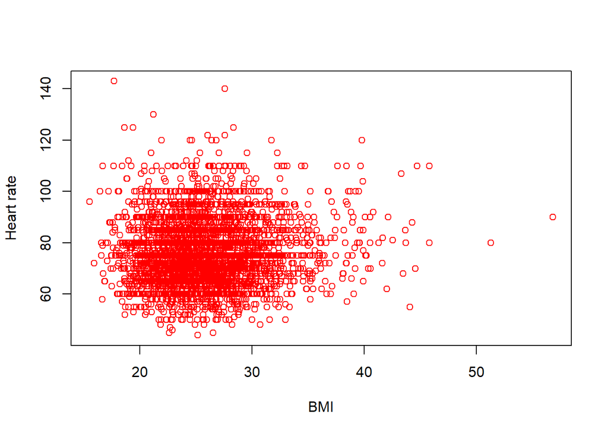

```r
# Scatter plot: BMI vs heart rate
plot(heart_data$BMI, heart_data$heartRate,
     xlab = "BMI",
     ylab = "Heart rate",
     col  = "red")
```

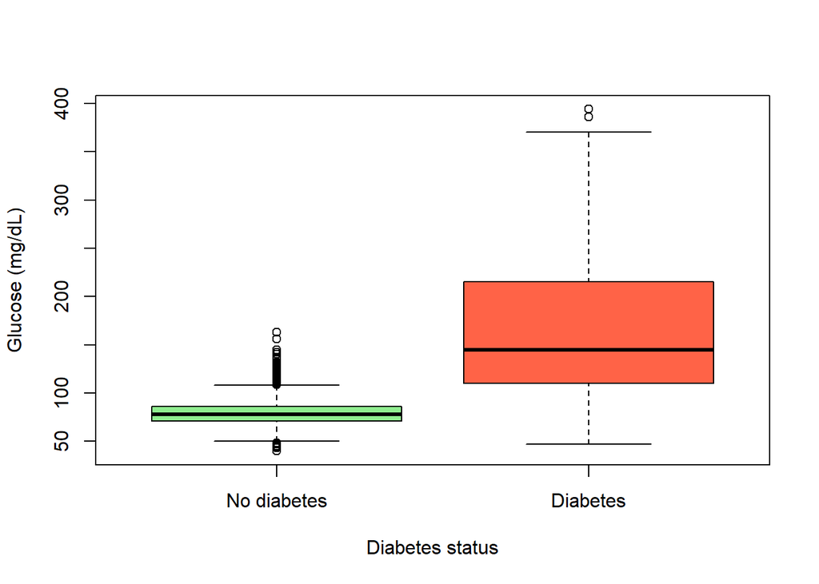

```r
# Boxplot: glucose by diabetes status
heart_data$diabetes_f <- factor(heart_data$diabetes,
                                levels = c(0, 1),
                                labels = c("No diabetes", "Diabetes"))

boxplot(glucose ~ diabetes_f, data = heart_data,
        xlab = "Diabetes status", ylab = "Glucose (mg/dL)",
        col = c("lightgreen", "tomato"))
```

- Create two plots with the `ggplot()` command, explain their meaning and save them as images (jpeg or bmp).

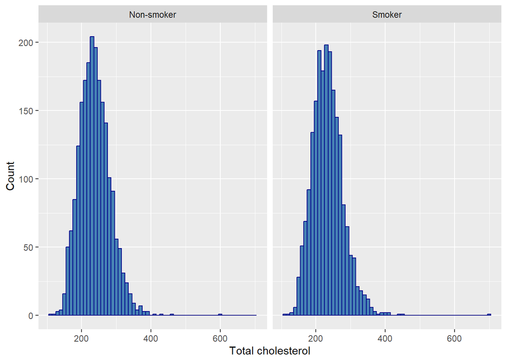

```r
heart_data$currentSmoker_f <- factor(heart_data$currentSmoker,
                                     levels = c(0, 1),
                                     labels = c("Non-smoker", "Smoker"))

# Distribution of total cholesterol by smoking status
ggplot(heart_data, aes(x = totChol)) +
  geom_histogram(fill = "steelblue", colour = "darkblue", binwidth = 10) +
  facet_wrap(~ currentSmoker_f) +
  labs(x = "Total cholesterol", y = "Count")
```

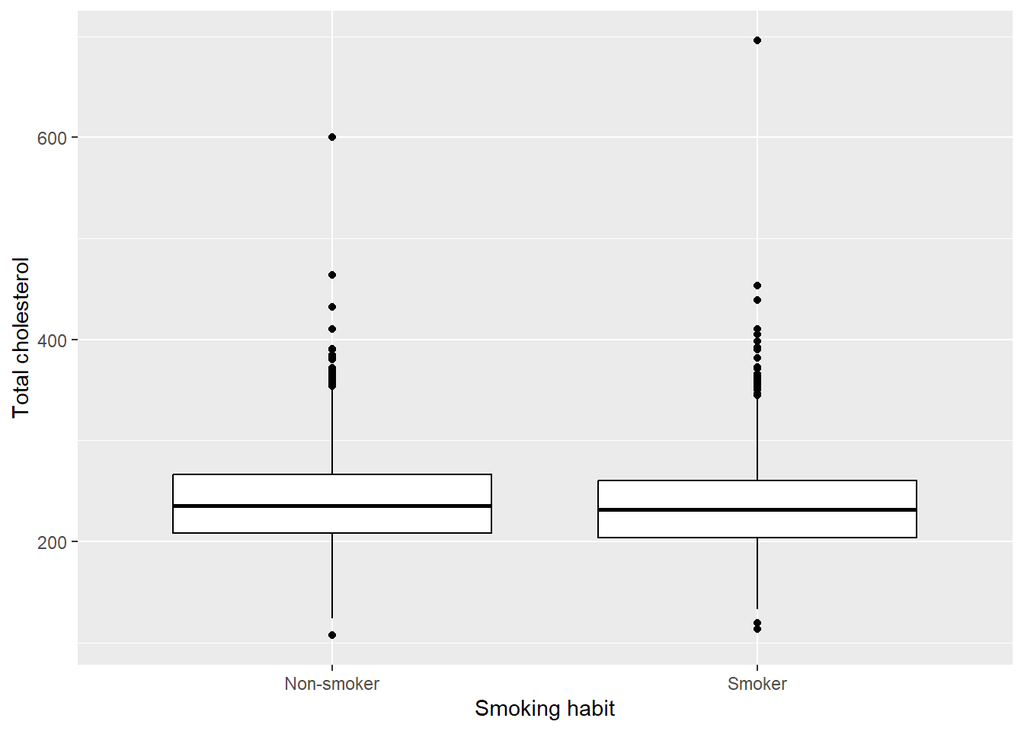

```r
# Total cholesterol by smoking status
ggplot(heart_data, aes(x = currentSmoker_f, y = totChol)) +
  geom_boxplot(colour = "black") +
  labs(x = "Smoking habit", y = "Total cholesterol") +
  theme(legend.position = "none")
```

The histograms show that total cholesterol has a similar, slightly right-skewed distribution in smokers and non-smokers, with a few extreme values above 400 mg/dL. The boxplot confirms it: the medians are almost identical (about 232 vs 236 mg/dL), so smoking status does not seem to be related to total cholesterol in this sample.

- Fit a linear regression between two of its variables step by step and comment on the results.

```r
# Correlation between systolic blood pressure and age
cor(heart_data$sysBP, heart_data$age)
```

```
## [1] 0.3940533
```

```r
# Linear model: systolic blood pressure as a function of age
model_heart <- lm(sysBP ~ age, data = heart_data)
summary(model_heart)
```

```
##
## Call:
## lm(formula = sysBP ~ age, data = heart_data)
##
## Residuals:
##     Min      1Q  Median      3Q     Max
## -57.382 -13.627  -2.627  10.182 148.042
##
## Coefficients:
##             Estimate Std. Error t value Pr(>|t|)
## (Intercept) 82.14199    1.82570   44.99   <2e-16 ***
## age          1.01276    0.03628   27.91   <2e-16 ***
## ---
## Signif. codes:  0 '***' 0.001 '**' 0.01 '*' 0.05 '.' 0.1 ' ' 1
##
## Residual standard error: 20.25 on 4238 degrees of freedom
## Multiple R-squared:  0.1553, Adjusted R-squared:  0.1551
## F-statistic:   779 on 1 and 4238 DF,  p-value: < 2.2e-16
```

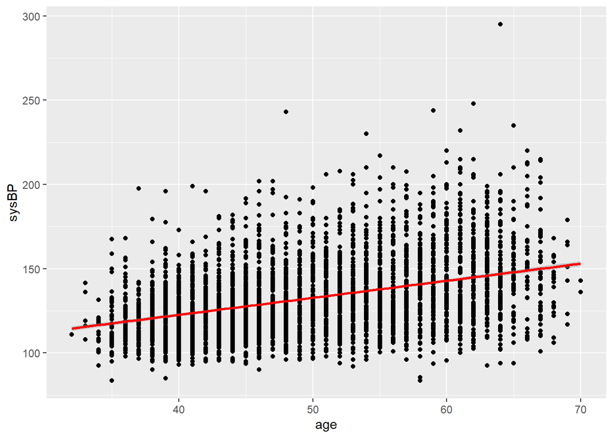

```r
# Scatter plot with the fitted line
ggplot(heart_data, aes(x = age, y = sysBP)) +
  geom_point() +
  geom_smooth(method = "lm", colour = "red")
```

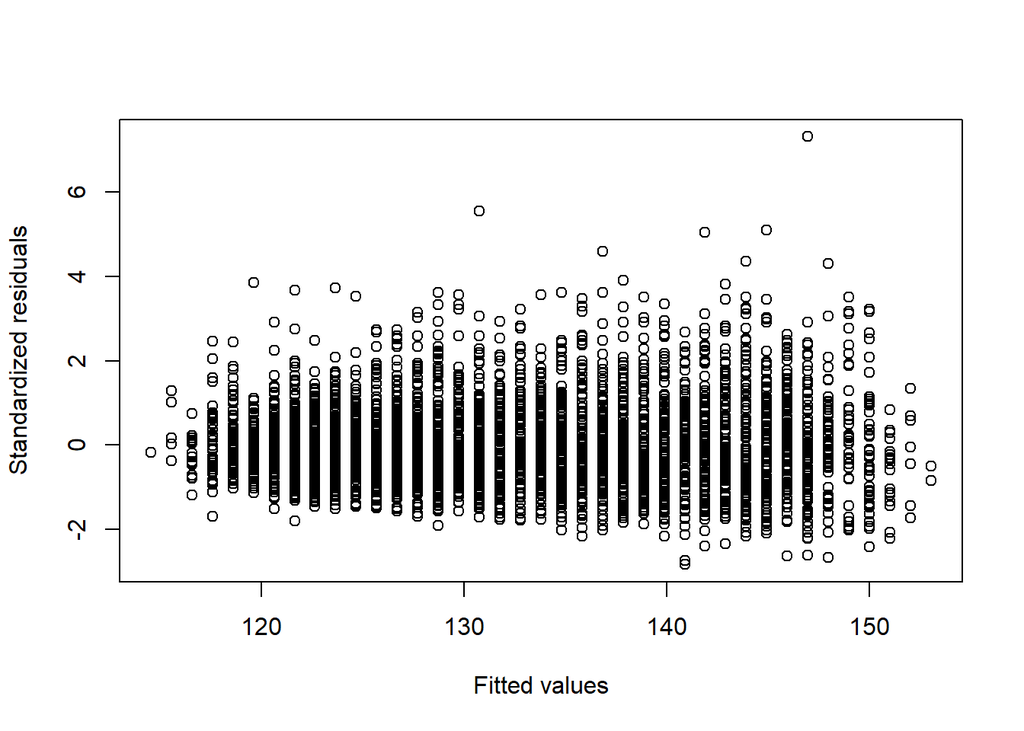

```r
# Model validation: standardized residuals vs fitted values
res_heart <- rstandard(model_heart)
predicted_heart <- fitted(model_heart)

plot(predicted_heart, res_heart,
     xlab = "Fitted values", ylab = "Standardized residuals")
```

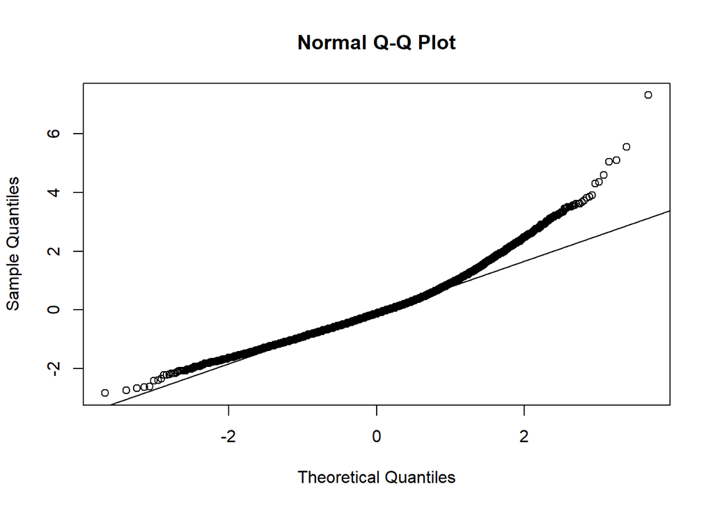

```r
# Normality of the residuals
qqnorm(res_heart)
qqline(res_heart)
```

There is a moderate positive correlation between age and systolic blood pressure (r about 0.39). The model estimates about 82 mmHg at age 0 (not meaningful on its own) and an increase of about 1 mmHg per year of age. The slope is highly significant (p < 0.001), but R-squared is only 0.16, so age explains about 16% of the variability in blood pressure and many other factors are missing. In the residuals-versus-fitted plot the variance increases for higher fitted values, and the Q-Q plot departs from the line in the upper tail (right-skewed residuals), so the normality and homoscedasticity assumptions are not fully satisfied. A log transformation of `sysBP` or a multiple model with more predictors (BMI, hypertension, sex) would be the natural next step.